# Homework 4 (Neural Networks)

Problem statement and Datasets  
• Your task for this homework will be to construct a neural network for both a regression  
and classification task. We'll be using the california dataset for the regression portion,  
and iris for classification. By the end of this hw you should be comfortable using sklearn's  
neural network on a dataset.  
• The data we'll be using for this hw will come directly from sklearn. Sklearn has built in  
datasets that we can download by running a single command.  
• Datasets: 2 dataset  
• California housing dataset  
• Iris dataset  
• sepal length (cm)  
• sepal width (cm)  
• petal length (cm)  
• petal width (cm)

California Housing Dataset • Attributes  
• MedInc  
• HouseAge  
• AveRooms  
• AveBedrms  
• Population  
• AveOccup  
• Latitude  
• Longitude

# Part1 Reading and Understanding the Data (Regression Part)

Import fetch_california_housing from sklearn. We then proceed to saving this data into  
data frame (X), and our target/labels in a variable (y). Use these variables (X data frame  
and y) for the regression portion of this homework.  
• TODO:  
• Print some basic statistics of your data.  
• Print some general information about your data using pandas.  
• By looking at our previous output, are there any missing values in this dataset? How  
do we know

```python
from sklearn.datasets import fetch_california_housing

california_housing = fetch_california_housing(as_frame=True)
import pandas as pd
import seaborn as sns
import matplotlib.pyplot as plt
import numpy as np
import warnings
warnings.filterwarnings("ignore")
```

```python
print(california_housing.DESCR)
```

```
.. _california_housing_dataset:

California Housing dataset
--------------------------

**Data Set Characteristics:**

    :Number of Instances: 20640

    :Number of Attributes: 8 numeric, predictive attributes and the target

    :Attribute Information:
        - MedInc        median income in block
        - HouseAge      median house age in block
        - AveRooms      average number of rooms
        - AveBedrms     average number of bedrooms
        - Population    block population
        - AveOccup      average house occupancy
        - Latitude      house block latitude
        - Longitude     house block longitude

    :Missing Attribute Values: None

This dataset was obtained from the StatLib repository.
http://lib.stat.cmu.edu/datasets/

The target variable is the median house value for California districts.

This dataset was derived from the 1990 U.S. census, using one row per census
block group. A block group is the smallest geographical unit for which the U.S.
Census Bureau publishes sample data (a block group typically has a population
of 600 to 3,000 people).

It can be downloaded/loaded using the
:func:`sklearn.datasets.fetch_california_housing` function.

.. topic:: References

    - Pace, R. Kelley and Ronald Barry, Sparse Spatial Autoregressions,
      Statistics and Probability Letters, 33 (1997) 291-297
```

```python
california_housing.frame
```

|  | MedInc | HouseAge | AveRooms | AveBedrms | Population | AveOccup | Latitude | Longitude | MedHouseVal |
| --- | --- | --- | --- | --- | --- | --- | --- | --- | --- |
| 0 | 8.3252 | 41.0 | 6.984127 | 1.023810 | 322.0 | 2.555556 | 37.88 | -122.23 | 4.526 |
| 1 | 8.3014 | 21.0 | 6.238137 | 0.971880 | 2401.0 | 2.109842 | 37.86 | -122.22 | 3.585 |
| 2 | 7.2574 | 52.0 | 8.288136 | 1.073446 | 496.0 | 2.802260 | 37.85 | -122.24 | 3.521 |
| 3 | 5.6431 | 52.0 | 5.817352 | 1.073059 | 558.0 | 2.547945 | 37.85 | -122.25 | 3.413 |
| 4 | 3.8462 | 52.0 | 6.281853 | 1.081081 | 565.0 | 2.181467 | 37.85 | -122.25 | 3.422 |
| ... | ... | ... | ... | ... | ... | ... | ... | ... | ... |
| 20635 | 1.5603 | 25.0 | 5.045455 | 1.133333 | 845.0 | 2.560606 | 39.48 | -121.09 | 0.781 |
| 20636 | 2.5568 | 18.0 | 6.114035 | 1.315789 | 356.0 | 3.122807 | 39.49 | -121.21 | 0.771 |
| 20637 | 1.7000 | 17.0 | 5.205543 | 1.120092 | 1007.0 | 2.325635 | 39.43 | -121.22 | 0.923 |
| 20638 | 1.8672 | 18.0 | 5.329513 | 1.171920 | 741.0 | 2.123209 | 39.43 | -121.32 | 0.847 |
| 20639 | 2.3886 | 16.0 | 5.254717 | 1.162264 | 1387.0 | 2.616981 | 39.37 | -121.24 | 0.894 |

20640 rows × 9 columns

```python
california_housing.frame.head()
```

|  | MedInc | HouseAge | AveRooms | AveBedrms | Population | AveOccup | Latitude | Longitude | MedHouseVal |
| --- | --- | --- | --- | --- | --- | --- | --- | --- | --- |
| 0 | 8.3252 | 41.0 | 6.984127 | 1.023810 | 322.0 | 2.555556 | 37.88 | -122.23 | 4.526 |
| 1 | 8.3014 | 21.0 | 6.238137 | 0.971880 | 2401.0 | 2.109842 | 37.86 | -122.22 | 3.585 |
| 2 | 7.2574 | 52.0 | 8.288136 | 1.073446 | 496.0 | 2.802260 | 37.85 | -122.24 | 3.521 |
| 3 | 5.6431 | 52.0 | 5.817352 | 1.073059 | 558.0 | 2.547945 | 37.85 | -122.25 | 3.413 |
| 4 | 3.8462 | 52.0 | 6.281853 | 1.081081 | 565.0 | 2.181467 | 37.85 | -122.25 | 3.422 |

```python
california_housing.frame.info()
```

```
<class 'pandas.core.frame.DataFrame'>
RangeIndex: 20640 entries, 0 to 20639
Data columns (total 9 columns):
 #   Column       Non-Null Count  Dtype
---  ------       --------------  -----
 0   MedInc       20640 non-null  float64
 1   HouseAge     20640 non-null  float64
 2   AveRooms     20640 non-null  float64
 3   AveBedrms    20640 non-null  float64
 4   Population   20640 non-null  float64
 5   AveOccup     20640 non-null  float64
 6   Latitude     20640 non-null  float64
 7   Longitude    20640 non-null  float64
 8   MedHouseVal  20640 non-null  float64
dtypes: float64(9)
memory usage: 1.4 MB
```

```python
california_housing.frame.describe()
```

|  | MedInc | HouseAge | AveRooms | AveBedrms | Population | AveOccup | Latitude | Longitude | MedHouseVal |
| --- | --- | --- | --- | --- | --- | --- | --- | --- | --- |
| count | 20640.000000 | 20640.000000 | 20640.000000 | 20640.000000 | 20640.000000 | 20640.000000 | 20640.000000 | 20640.000000 | 20640.000000 |
| mean | 3.870671 | 28.639486 | 5.429000 | 1.096675 | 1425.476744 | 3.070655 | 35.631861 | -119.569704 | 2.068558 |
| std | 1.899822 | 12.585558 | 2.474173 | 0.473911 | 1132.462122 | 10.386050 | 2.135952 | 2.003532 | 1.153956 |
| min | 0.499900 | 1.000000 | 0.846154 | 0.333333 | 3.000000 | 0.692308 | 32.540000 | -124.350000 | 0.149990 |
| 25% | 2.563400 | 18.000000 | 4.440716 | 1.006079 | 787.000000 | 2.429741 | 33.930000 | -121.800000 | 1.196000 |
| 50% | 3.534800 | 29.000000 | 5.229129 | 1.048780 | 1166.000000 | 2.818116 | 34.260000 | -118.490000 | 1.797000 |
| 75% | 4.743250 | 37.000000 | 6.052381 | 1.099526 | 1725.000000 | 3.282261 | 37.710000 | -118.010000 | 2.647250 |
| max | 15.000100 | 52.000000 | 141.909091 | 34.066667 | 35682.000000 | 1243.333333 | 41.950000 | -114.310000 | 5.000010 |

```python
california_housing.frame.isnull().sum()
```

```
MedInc         0
HouseAge       0
AveRooms       0
AveBedrms      0
Population     0
AveOccup       0
Latitude       0
Longitude      0
MedHouseVal    0
dtype: int64
```

#### No, We do NOT have any missed values because every column has 20640 non-null values

# Part 2 Visualization

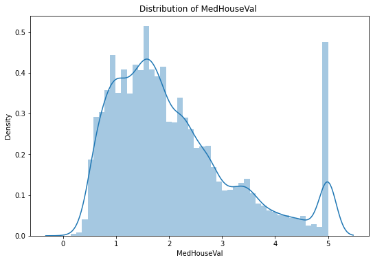

```python
plt.figure(figsize=(30,20))

plt.subplot(3,3,1)
plt.title('Distribution of MedHouseVal ')
sns.distplot(california_housing.frame.MedHouseVal)

plt.show()
```

#### QUESTION:

What can you conclude from the plot you created?

#### ANSWER

So, the maximum of Median House Value is 5 with disctibution ~0.5, and median of House Value is between 1 and 2.The smallest is 0

# Part 2 Visualization

[figure not shown]

```python
plt.figure(figsize=(30,10))
plt.scatter(california_housing.frame['Population'],california_housing.frame['MedHouseVal'],color="Green")

plt.title('Hypothetical:Student age group and GMAT Score')

plt.xlabel('Age')

plt.ylabel('Score')

plt.show()
```

#### QUESTION:

What can you conclude from the plot you created?

#### ANSWER

# Part 2 Visualization

# Part 2 Visualization

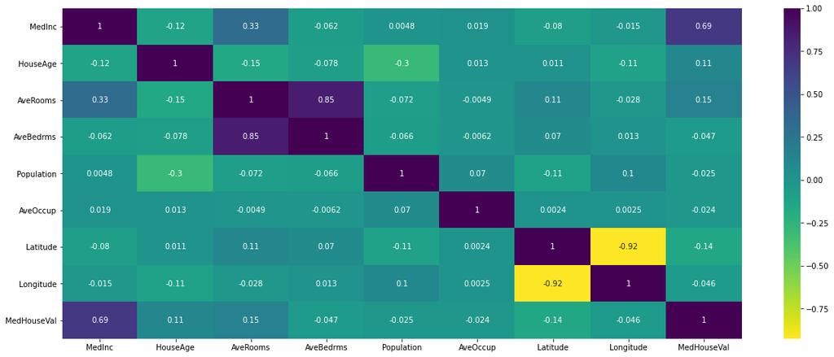

```python
plt.figure(figsize = (20, 8))
sns.heatmap(california_housing.frame.corr(), annot = True, cmap="viridis_r")
plt.show()
```

#### QUESTION

• What can you conclude from the heatmap you created?

#### ANSWER

# Part 2 Visualization

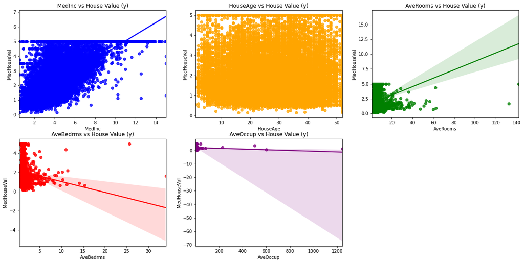

```python
plt.figure(figsize=(20,15))

plt.subplot(3,3,1)
plt.title('MedInc vs House Value (y)')
sns.regplot(california_housing.frame['MedInc'],california_housing.frame['MedHouseVal'],color="blue")

plt.subplot(3,3,2)
plt.title('HouseAge vs House Value (y)')
sns.regplot(california_housing.frame['HouseAge'],california_housing.frame['MedHouseVal'],color="orange")

plt.subplot(3,3,3)
plt.title('AveRooms vs House Value (y)')
sns.regplot(california_housing.frame['AveRooms'],california_housing.frame['MedHouseVal'],color="green")

plt.subplot(3,3,4)
plt.title('AveBedrms vs House Value (y)')
sns.regplot(california_housing.frame['AveBedrms'],california_housing.frame['MedHouseVal'],color="red")

plt.subplot(3,3,5)
plt.title('AveOccup vs House Value (y)')
sns.regplot(california_housing.frame['AveOccup'],california_housing.frame['MedHouseVal'],color="purple")



plt.show()
```

#### QUESTION

What can you conclude from the plots you created

#### ANSWER

1.MedInc and AveRooms have a poitive correlations.  
2. HouseAge has Unknown correlation  
3. AveBedrms and AveOccup have a negative correlations

# Part 2 Visualization

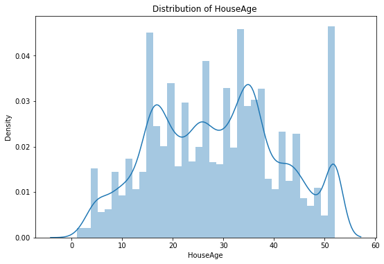

```python
plt.figure(figsize=(30,20))

plt.subplot(3,3,1)
plt.title('Distribution of HouseAge ')
sns.distplot(california_housing.frame.HouseAge)

plt.show()
```

#### Question

What can you conclude from the plot you created?

#### ANSWER

# Part 3 Model Creation and Evaluation

```python
from sklearn.model_selection import train_test_split
X=california_housing.frame[['MedInc','HouseAge','AveRooms','AveBedrms','Population','AveOccup','Latitude','Longitude']]
y=california_housing.frame['MedHouseVal']
X_train, X_test, y_train, y_test = train_test_split(X, y, test_size=0.3)
```

```python
from sklearn.neural_network import MLPRegressor
mlp = MLPRegressor(max_iter=500, activation='relu')
mlp.fit(X_train,y_train)
```

```
MLPRegressor(max_iter=500)
```

```python
predictions = mlp.predict(X_test)
```

```python
#from sklearn.metrics import classification_report, confusion_matrix
#print(confusion_matrix(y_test,predictions))
#print(classification_report(y_test,predictions))
```

```python
from sklearn import metrics
print('MAE:', metrics.mean_absolute_error(y_test, predictions))
print('MSE:', metrics.mean_squared_error(y_test, predictions))
print('RMSE:', np.sqrt(metrics.mean_squared_error(y_test, predictions)))
```

```
MAE: 0.5855732916720062
MSE: 0.6370122202825456
RMSE: 0.7981304531732551
```

```python
#mlp2 = MLPClassifier(max_iter=3000, activation='logistic', hidden_layer_sizes=(1000,900))
#mlp2.fit(X_train,y_train)
#print(confusion_matrix(y_test,predictions))
#print(classification_report(y_test,predictions))
```

```python
from sklearn.metrics import r2_score
print('R2 Score:', r2_score(y_test, predictions))
```

```
R2 Score: 0.5177463872484925
```

# Part 3 Model Creation and Evaluation

How did your model perform?  
• Try experimenting with different hidden layer sizes.  
• Try using gridsearchCV to find the best set of parameters.  
• Write the best setting working.  
• Also, hopefully you noticed that our data contains outliers. You can also try removing  
them to see if that improves performance

# Part 4 Reading and Understanding the Data (Classification part)

```python
from sklearn.datasets import load_iris

iris = load_iris(as_frame=True)
```

```python
iris.frame.head()
```

|  | sepal length (cm) | sepal width (cm) | petal length (cm) | petal width (cm) | target |
| --- | --- | --- | --- | --- | --- |
| 0 | 5.1 | 3.5 | 1.4 | 0.2 | 0 |
| 1 | 4.9 | 3.0 | 1.4 | 0.2 | 0 |
| 2 | 4.7 | 3.2 | 1.3 | 0.2 | 0 |
| 3 | 4.6 | 3.1 | 1.5 | 0.2 | 0 |
| 4 | 5.0 | 3.6 | 1.4 | 0.2 | 0 |

```python
iris.frame.info()
```

```
<class 'pandas.core.frame.DataFrame'>
RangeIndex: 150 entries, 0 to 149
Data columns (total 5 columns):
 #   Column             Non-Null Count  Dtype
---  ------             --------------  -----
 0   sepal length (cm)  150 non-null    float64
 1   sepal width (cm)   150 non-null    float64
 2   petal length (cm)  150 non-null    float64
 3   petal width (cm)   150 non-null    float64
 4   target             150 non-null    int32
dtypes: float64(4), int32(1)
memory usage: 5.4 KB
```

```python
iris.frame.describe()
```

|  | sepal length (cm) | sepal width (cm) | petal length (cm) | petal width (cm) | target |
| --- | --- | --- | --- | --- | --- |
| count | 150.000000 | 150.000000 | 150.000000 | 150.000000 | 150.000000 |
| mean | 5.843333 | 3.057333 | 3.758000 | 1.199333 | 1.000000 |
| std | 0.828066 | 0.435866 | 1.765298 | 0.762238 | 0.819232 |
| min | 4.300000 | 2.000000 | 1.000000 | 0.100000 | 0.000000 |
| 25% | 5.100000 | 2.800000 | 1.600000 | 0.300000 | 0.000000 |
| 50% | 5.800000 | 3.000000 | 4.350000 | 1.300000 | 1.000000 |
| 75% | 6.400000 | 3.300000 | 5.100000 | 1.800000 | 2.000000 |
| max | 7.900000 | 4.400000 | 6.900000 | 2.500000 | 2.000000 |

```python
iris.frame.isnull().sum()
```

```
sepal length (cm)    0
sepal width (cm)     0
petal length (cm)    0
petal width (cm)     0
target               0
dtype: int64
```

#### No, We do NOT have any missed values because every column has 150 non-null values

# Part 4 Reading and Understanding the Data (Classification part)

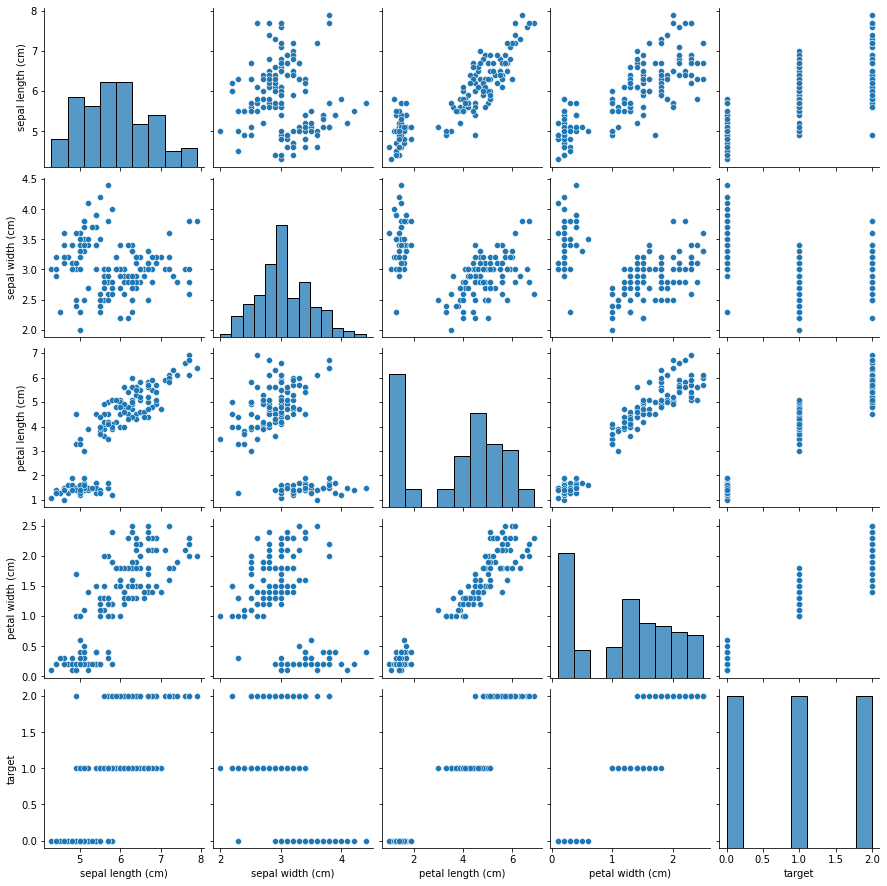

```python
sns.pairplot(iris.frame)
plt.show()
```

# Part 4 Reading and Understanding the Data (Classification part)

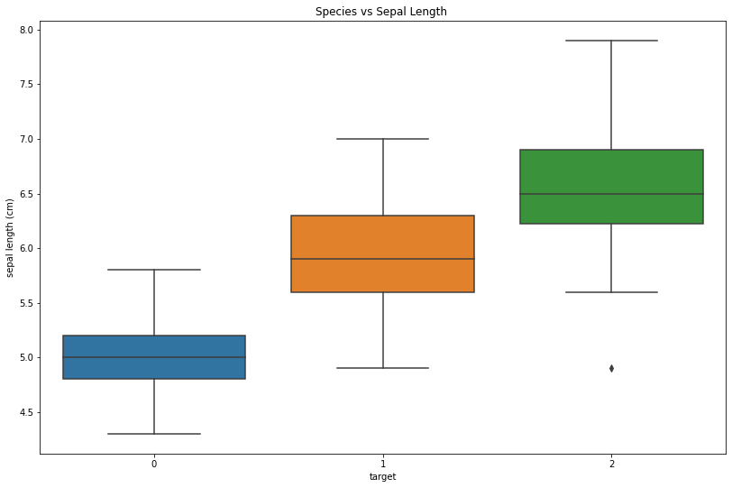

```python
plt. subplots(figsize=(30,30))

plt.subplot(3,2,1)

sns.boxplot(y="sepal length (cm)",x='target',data=iris.frame).set_title('Species vs Sepal Length ')
plt.show()
```

#### Question

What can you conclude from the plots you created?

#### Answer

# Part 4 Reading and Understanding the Data (Classification part)

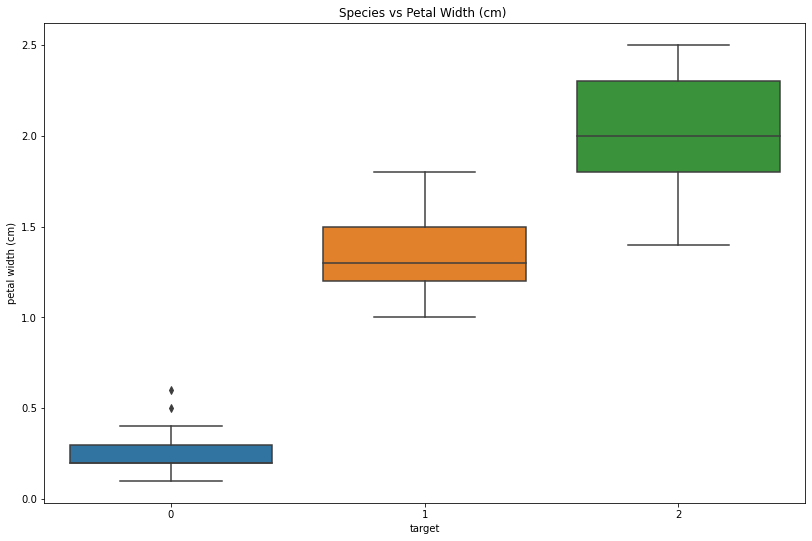

```python
plt. subplots(figsize=(30,30))

plt.subplot(3,2,1)

sns.boxplot(y="petal width (cm)",x='target',data=iris.frame).set_title('Species vs Petal Width (cm) ')
plt.show()
```

#### QUESTION

What can you conclude from the plots you created?

#### ANSWER

# Part 4 Reading and Understanding the Data (Classification part)

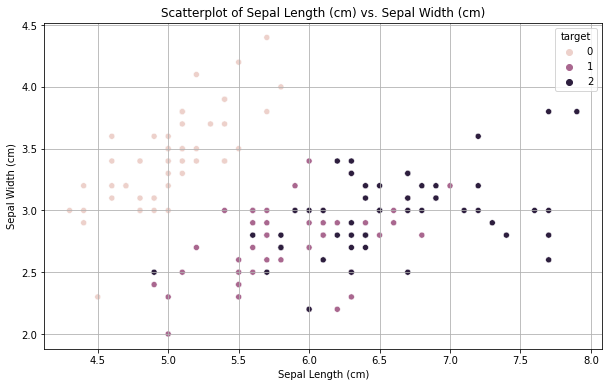

```python
plt.figure(figsize=(10,6))
X2 = iris.frame["sepal length (cm)"]
X1 = iris.frame["sepal width (cm)"]
sns.scatterplot(x=X2,y=X1,hue="target",data=iris.frame)
plt.xlabel('Sepal Length (cm)')
plt.ylabel('Sepal Width (cm)')
plt.title('Scatterplot of Sepal Length (cm) vs. Sepal Width (cm)')
plt.grid()
```

#### QUESTION

What can you conclude from the plots you created?

#### ANSWER

```python
iris.frame
```

|  | sepal length (cm) | sepal width (cm) | petal length (cm) | petal width (cm) | target |
| --- | --- | --- | --- | --- | --- |
| 0 | 5.1 | 3.5 | 1.4 | 0.2 | 0 |
| 1 | 4.9 | 3.0 | 1.4 | 0.2 | 0 |
| 2 | 4.7 | 3.2 | 1.3 | 0.2 | 0 |
| 3 | 4.6 | 3.1 | 1.5 | 0.2 | 0 |
| 4 | 5.0 | 3.6 | 1.4 | 0.2 | 0 |
| ... | ... | ... | ... | ... | ... |
| 145 | 6.7 | 3.0 | 5.2 | 2.3 | 2 |
| 146 | 6.3 | 2.5 | 5.0 | 1.9 | 2 |
| 147 | 6.5 | 3.0 | 5.2 | 2.0 | 2 |
| 148 | 6.2 | 3.4 | 5.4 | 2.3 | 2 |
| 149 | 5.9 | 3.0 | 5.1 | 1.8 | 2 |

150 rows × 5 columns

# Part 5: Model creation and evaluation

• Remove species column from the dataset  
• Perform the following  
1.Scale the data  
2.Split your data into a training and testing set, with test size of 0.30  
3.Create a neural network for classification using sklearn. See  
sklearn.neural_network.MLPClassifier if you need help. Use a hidden layers of size  
256->128->64->32, and activation function 'relu'.  
4.Run the test data through your model to obtain predictions. Save these predictions  
into a variable called 'predictions'.  
5.Print the mean accuracy of your model on the given test data and labels.

```python
from sklearn.model_selection import train_test_split
X=iris.frame[['sepal length (cm)','sepal width (cm)','petal length (cm)','petal width (cm)']]
y=iris.frame['target']
X_train, X_test, y_train, y_test = train_test_split(X, y, test_size=0.3)
```

```python
from sklearn.neural_network import MLPClassifier
mlp = MLPClassifier(max_iter=500, activation='relu')
mlp.fit(X_train,y_train)
```

```
MLPClassifier(max_iter=500)
```

```python
predictions = mlp.predict(X_test)
```

```python
from sklearn.metrics import classification_report, confusion_matrix
print(classification_report(y_test,predictions))
print(confusion_matrix(y_test,predictions))
```

```
              precision    recall  f1-score   support

           0       1.00      1.00      1.00        17
           1       1.00      0.93      0.97        15
           2       0.93      1.00      0.96        13

    accuracy                           0.98        45
   macro avg       0.98      0.98      0.98        45
weighted avg       0.98      0.98      0.98        45

[[17  0  0]
 [ 0 14  1]
 [ 0  0 13]]
```

```python
mlp2 = MLPClassifier(max_iter=3000, activation='logistic', hidden_layer_sizes=(1000,900))
mlp2.fit(X_train,y_train)
predictions2 = mlp2.predict(X_test)
print(confusion_matrix(y_test,predictions2))
x=(classification_report(y_test,predictions2))
print(x)
```

```
[[17  0  0]
 [ 0 14  1]
 [ 0  0 13]]
              precision    recall  f1-score   support

           0       1.00      1.00      1.00        17
           1       1.00      0.93      0.97        15
           2       0.93      1.00      0.96        13

    accuracy                           0.98        45
   macro avg       0.98      0.98      0.98        45
weighted avg       0.98      0.98      0.98        45
```

```python
from sklearn.metrics import r2_score
print('R2 Score:', r2_score(y_test, predictions))
```

```
R2 Score: 0.9662668665667167
```

# Part 5 Model Creation and Evaluation

• How did your model perform?  
• Try experimenting with different hidden layer sizes.  
• Try using gridsearchCV to find the best set of parameters.  
• Save any cells you use for experimenting so that we can see what you tried.  
• What works best for this model?

# Part 5 Model creation and evaluation